# Creative Assignment 1

Sara Arman

```r
library(tidycensus)
library(tidyverse)
```

```r
library(ggplot2)
library(viridis)
library(wesanderson)
library(colorBlindness)
library(ggthemes)
library(quantreg)
```

## Variables

###For this assignment I am using the same variables Carole provided in the tutorial, I am also using the census data, but in Clark County, Nevada.

Carole’s variables are:

1.Majority race/ethnicity (categorical) 2.Average household size (continuous) 3.Median age of residents (continuous) 4.Percent of households who live in rented homes (continuous) 5.Urban or rural (categorical) 6.Population of the tract (continuous)

```r
vars <- c(tot_hh = "H001001",
         tot_rural_hh = "H002005",
         tot_rent_hh = "H004004",
         avg_hh_size = "H012001",
         tot_pop = "P003001",
         nh_white_pop = "P005003",
         nh_black_pop = "P005004",
         nh_asian_pop = "P005006",
         hispanic_pop = "P005010",
         med_age = "P013001")

CL_tracts <- get_decennial(geography = "tract", variables = vars,
                           state = "NV", county = "Clark",
                           output = "wide") %>%
  mutate(rural = (tot_rural_hh == tot_hh) ,
         pct_rental = tot_rent_hh / tot_hh,
         majority_race_eth = case_when(
           nh_white_pop / tot_pop > 0.5 ~ "nh_white",
           nh_black_pop / tot_pop > 0.5 ~ "nh_black",
           nh_asian_pop / tot_pop > 0.5 ~ "nh_asian",
           hispanic_pop / tot_pop > 0.5 ~ "hispanic",
           (nh_white_pop + nh_black_pop + nh_asian_pop + hispanic_pop) /
             tot_pop < 0.5 ~ "other",
           TRUE ~ "None")) %>%
  filter(tot_pop > 0, tot_hh > 0) %>%
  select(GEOID, rural, majority_race_eth,
         pct_rental, avg_hh_size, tot_pop, med_age)
```

```
## Using Census Summary File 1
```

### Graph 1: Box Plot, Race/Ethnicity and Average Household Size

With this Box Plot, I wanted to examine the relationship between Majority Race and Ethnicity (categorical), and average household size(continous).

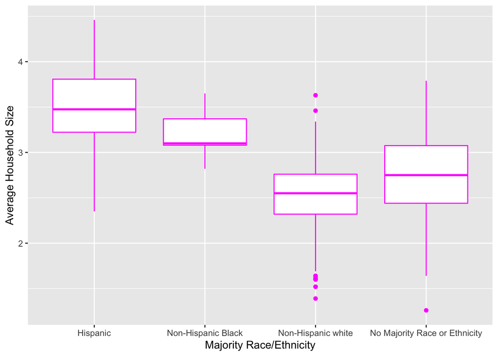

```r
ggplot(CL_tracts,
      aes(x = majority_race_eth,
           y = avg_hh_size)) +

  geom_boxplot(linetype = 1, color = "magenta") +
  scale_x_discrete(name = "Majority Race/Ethnicity",
                       labels = c("Hispanic",
                                  "Non-Hispanic Black", "Non-Hispanic white","No Majority Race or Ethnicity")) +
  scale_y_continuous(name = "Average Household Size")
```

### Graph 2: Scatter Plot -Percent Rental and Average Household Size

With this plot, I was interested in seeing if there was any correlation between household size and percent rental, my graph showed me that there is no correlation. I took the labels, theme, and sequence from the bottom part of the code from Carole’s first graph with the 7 variables.

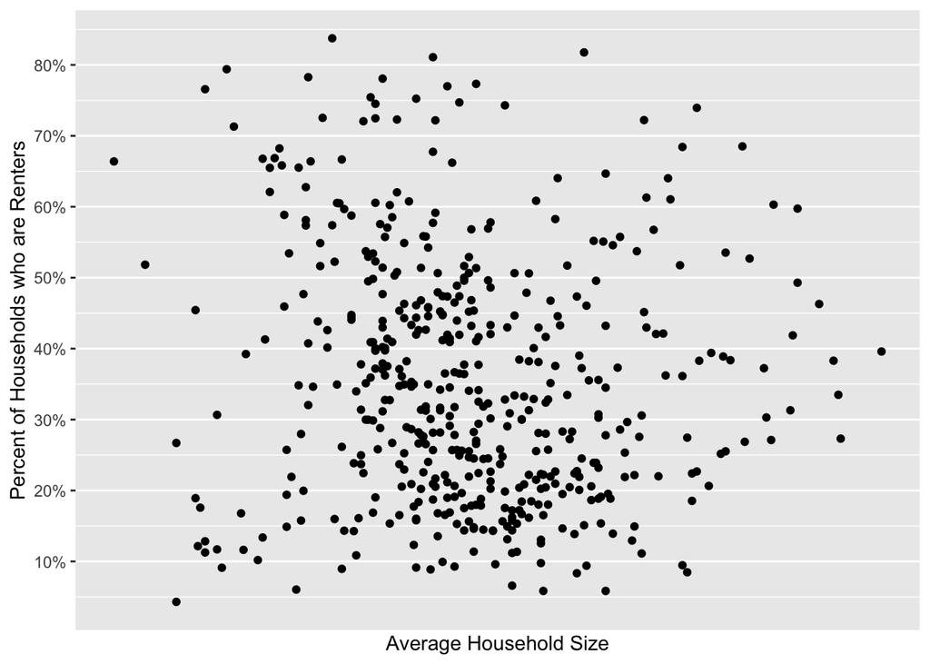

```r
ggplot(CL_tracts,
      aes(x = avg_hh_size,
           y = pct_rental,
           )) +
  geom_point() +
  scale_x_continuous(name = "Average Household Size",
                     breaks = seq(0, 1, by = 0.1),
                     labels = paste(seq(0, 100, by = 10), "%", sep = "")) +
  scale_y_continuous(name = "Percent of Households who are Renters",
                     breaks = seq(0, 1, by = 0.1),
                     labels = paste(seq(0, 100, by = 10), "%", sep = "")) +
  theme(legend.key.size = unit(0.1, "cm"))
```

### Graph 3: Violin Graph, Percent Rental and Race/Ethnicity

After doing some reading, I found out that Violin charts are supposed to show density in a different way than mean and median can, so I decided to use a violin chart to explore the relationship between percentage of households who are renting, and race/ethnicity. From the graph, it looked like Hispanic and Non-Hispanic Black households were more likely to rent, though I could be interpreting it wrong. I took the code off of the ggplot cheat sheet provided in the tutorial.

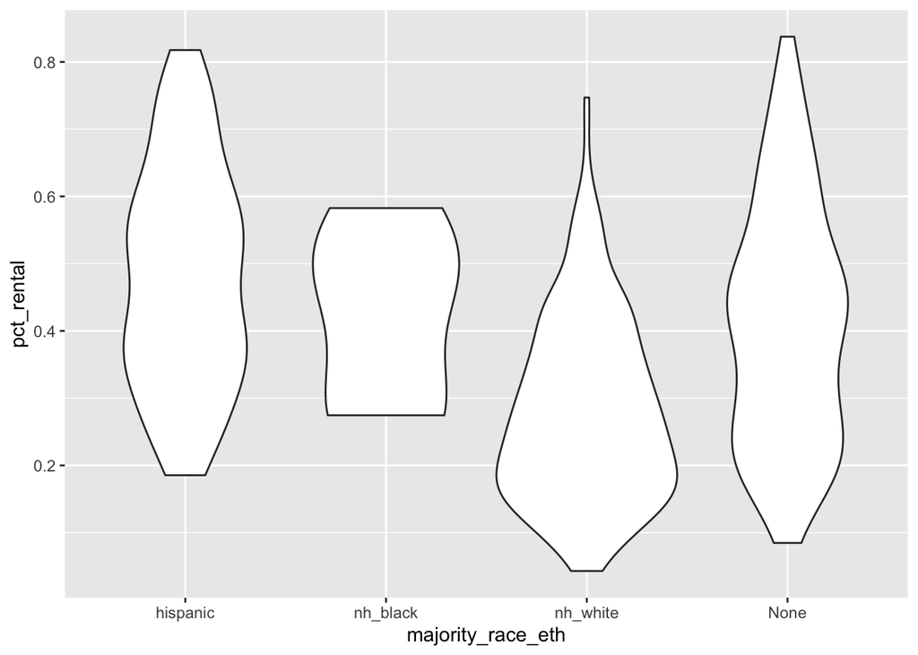

```r
ggplot(CL_tracts,
      aes(x = pct_rental,
           y = majority_race_eth,)) +
  geom_violin() +
  coord_flip()
```

### Graph 4: Histogram of Median Age in Clark County Nevada

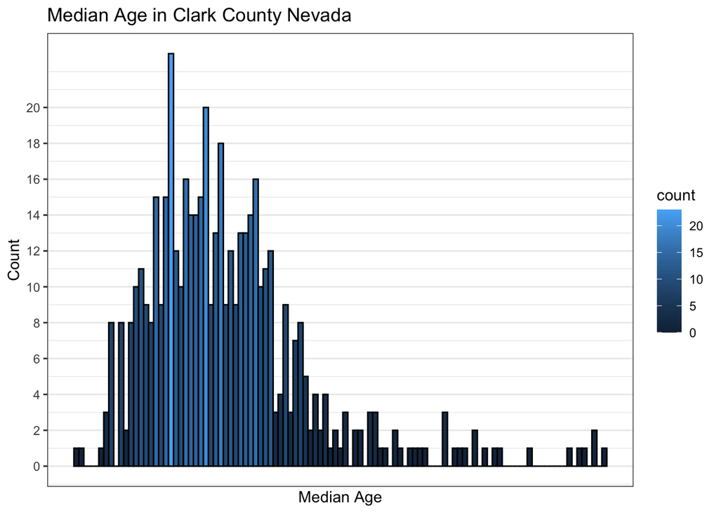

```r
ggplot(CL_tracts,
       aes(x = med_age)) +
geom_histogram(aes(fill = ..count..), binwidth = .5, color = "black", weight = 5) +
scale_x_continuous(name = "Median Age",
                   breaks = seq(0, 1, by = 1)) +
scale_y_continuous(name = "Count",
                  breaks = seq(0, 20, by = 2)) +
labs(title = 'Median Age in Clark County Nevada')+
 theme_bw()
```

```r
coord_flip()
```

[output not shown]

### Graph 5: Bar Chart (One Categorical Variable)

On the ggplot cheat sheet, it showed that bar charts are good for displaying one categorical variable. The reading for last week said something similar, but it helped to see this in practice.

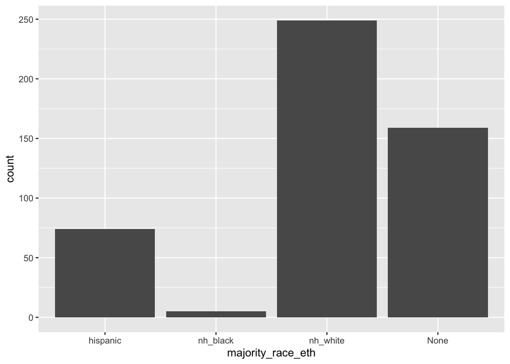

```r
ggplot(CL_tracts,
      aes(x = majority_race_eth)) +
  geom_bar()
```

```r
labs(title = 'Majority Race and Ethnicity Clark County Nevada')+
  theme_clean()
```

### Graph 6: Dot Plot of Total Population and Race/Ethnicity

I thought this graph would show the race/ethnicity of the entire population, but it doesn’t really show anything! I am going to keep trying to make a Dot Plot.

[figure not shown]

```r
ggplot(CL_tracts,
       aes(x = tot_pop,
           fill = tot_pop,
           size = tot_pop,
           color = majority_race_eth)) +
  geom_dotplot(binwidth = .5, stackdir = "center")+
  scale_x_continuous(name = "Total Population")+
  labs(title = 'Race, Ethnicity of Total Population in Clark County')+
  theme_bw()
```

### Graph 7: Dot Plot of Average Household Size by Rural or Urban Area

I tried to make another dotplot, but this time with average household size, by rural or urban area.I don’t think the way I have represented the data makes a lot of sense, maybe dot plots are better for categorical variables and Household size is continous. (Thank you to Julia for helping me with both Dotplots!)

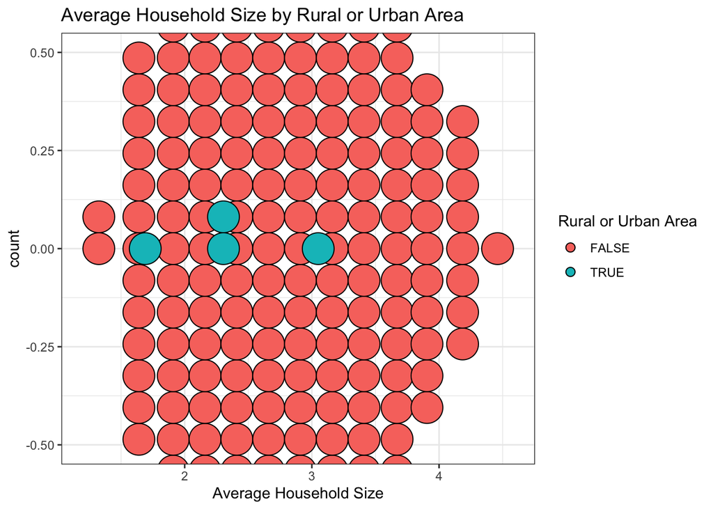

```r
ggplot(CL_tracts,
       aes(x = avg_hh_size,
           fill = rural)) +
  geom_dotplot(binwidth = .25, stackdir = "centerwhole")+
  scale_x_continuous(name = "Average Household Size")+
  scale_fill_discrete (name = "Rural or Urban Area") +
  labs(title = 'Average Household Size by Rural or Urban Area')+

  theme_bw()
```

### Graph 8: Density Graph.

On the GGplot cheat sheet I saw a density graph was useful to represent one continuous variable, so I used it to represent median age.

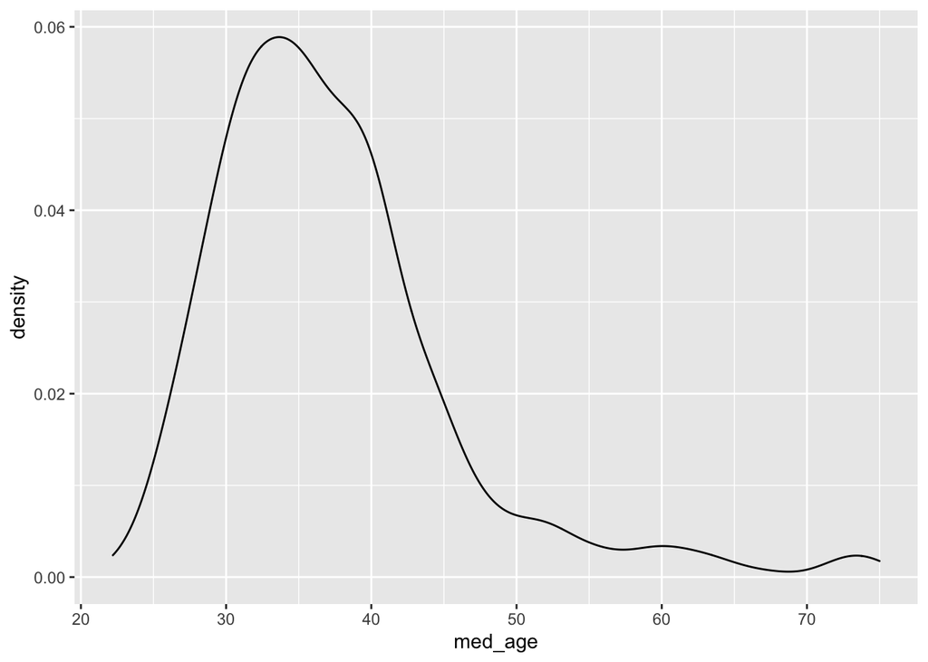

```r
ggplot(CL_tracts,
      aes(x = med_age,)) +
  geom_density()
```

### Graph 9: Quantile Graph to Represent Continous X (Median Age) and Continous Y (Average Household Size)

I saw the quantile graph on the gg cheat sheet to represent 2 continous variables. Once I graphed it I had to install “quantreg” to be able to run the graph.

```
## Smoothing formula not specified. Using: y ~ x
```

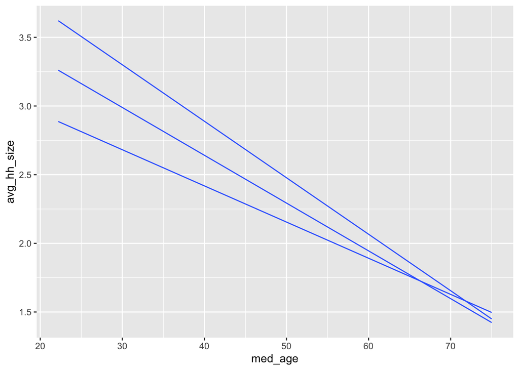

```r
ggplot(CL_tracts,
      aes(x = med_age,
          y = avg_hh_size)) +
geom_quantile()
```

```r
 labs(title = 'Average Household Size by Median Age')+
theme_classic()
```

### Graph 10: “Raster” Graph to Represent 3 variables

[figure not shown]

```r
ggplot(CL_tracts,
      aes(x = med_age,
          y = pct_rental,
          size = avg_hh_size)) +
geom_raster()
```

```r
 labs(title = 'Percent of Households Renting by Median Age in Clark County')+
theme_bw()
```